# homero_bennet.fixed

## **Mariposa Malaquita (Siproeta stelenes)**

[figure not shown]

La mariposa [*Malaquita*](https://mexico.inaturalist.org/taxa/50336-Siproeta-stelenes) con una taxonomía:

> *Filo* Arthropoda  
> *Clase* Insecta  
> *Orden* [Lepidóptera](https://es.wikipedia.org/wiki/Lepidoptera)

En este presente proyecto se hace uso del lenguaje de programación [Phyton](https://www.python.org/) que a partir de archivos de datos obtenidos de la página web [GBIF](https://www.gbif.org/) contienen información de la data, coordenadas, y otros datos de interés, estos sean procesados para divisar gráficos estadísticos y gráficos espaciales, los siguientes archivos se descargaron:

> [*GBIF.org (05 March 2025) GBIF Occurrence Download*](https://doi.org/10.15468/dl.c9qhmu)  
> [GBIF.org (07 March 2025) GBIF Occurrence Download](https://doi.org/10.15468/dl.mvkm2c).

En el presente trabajo se seleccionaron solo las observaciones de la especie **Siproeta stelenes** y la especie **Siproeta stelenes ssp biplagiata**, se seleccionaron las observaciones que presentasen coordenadas geográficas de la observación.

## **Importación de las librerías necesarias en el lenguaje de Programación Python**

Para el procesado de la información de la especie *Siproeta stelenes*, se instalaron / cargaron las librerías necesarias para el manejo de:

> Series de datos  
> Datos vectoriales  
> Datos matriciales  
> Datos en formato geoespacial  
> Librerias matemáticas  
> Librerias de graficado interactivo

En el lenguaje de programación Phyton se usaron las siguientes librerias:

> Pandas  
> Geopandas  
> Mathplot  
> Folium  
> Mapclassify  
> leafmap

```python
import geopandas as gpd
import pandas as pd
import matplotlib.pyplot as plt
import plotly.express as px

import folium # Para usar la función explore() en elaboración de mapas web interactivos

!pip install mapclassify --quiet

import mapclassify # Para usarse en mapas de coropletas
```

```
   ━━━━━━━━━━━━━━━━━━━━━━━━━━━━━━━━━━━━━━━━ 59.1/59.1 kB 4.0 MB/s eta 0:00:00
```

## **Lectura del archivo en formato csv de la especie de interés**

Los Archivo descargado de la página web *GBIF* están en el formato electrónico "[*CSV*](https://es.wikipedia.org/wiki/Valores_separados_por_comas)" con separador entre textos "[*Tab*](https://en.wikipedia.org/wiki/Tab-separated_values)" fueron importados para su lectura y su procesado uando el lenguaje [*Phyton*](https://www.python.org/).  
*Siproeta* es el archivo con las observaciones de la especie *Siproeta stelenes*  
*Siproeta_biplagiata* es el archivo con las observaciones de la especie *Siproeta stelenes ssp biplagiata*.

```python
malaquita01_df = pd.read_csv("siproeta.csv", sep='\t')
malaquita02_df = pd.read_csv("siproeta_biplagiata.csv", sep='\t')
```

### **Los resultados obtenidos de la importación del archivo son:**

Se obtuvieron la siguiente cantidad de registros:

> archivo malaquita01_df 17462 registros  
> archivo malaquira02_df 9294 registros

Cada archivo presenta 50 columnas de información:  
gbifID, datasetKey, occurrenceID, kingdom, phylum, class, order, family, genus, species  
infraspecificEpithet, taxonRank, scientificName, verbatimScientificName, verbatimScientificNameAuthorship, countryCode, locality, stateProvince, occurrenceStatus, individualCount, publishingOrgKey, decimalLatitude, decimalLongitude, coordinateUncertaintyInMeters,coordinatePrecision, elevation, elevationAccuracy, depth, depthAccuracy, eventDate, day, month, year, taxonKey, speciesKey, basisOfRecord, institutionCode, collectionCode, catalogNumber, recordNumber, identifiedBy, dateIdentified, license, rightsHolder, recordedBy, typeStatus, establishmentMeans, lastInterpreted, mediaType, issue

### **Procesado de la información**

### **Concatenado**

```python
malaquita_df = pd.concat([malaquita01_df,malaquita02_df])
len(malaquita_df)
```

```
26756
```

### **Graficado en histogramas por año y por país**

Se seleccionan los registros de presencias de la especie a partir del año 1980 (*malaquita_filtrado*) y la presencia de la especie por país (*malaquita_pais*).  
Se generó un gráfico histograma con el número de observaciones anuales y un segundo histograma con el número de registros por país, ambos a partir del año 1980.

```python
malaquita_filtrado = malaquita_df[malaquita_df['year'] >= 1980]

malaquita_year = malaquita_filtrado.groupby('year')['gbifID'].count().reset_index()

# Creación del gráfico de barras
fig = px.bar(
    malaquita_year,
    x='year',
    y='gbifID',
    title='Fig. 1 Género Siproeta (1980 - 2025)'
)

# Personalización
fig.update_layout(
    xaxis_title='Año',
    yaxis_title='Cantidad de registros',
    width=1000,    # Ancho de la figura
    height=600     # Alto de la figura
)
```

[interactive chart not shown]

```python
malaquita_pais = malaquita_filtrado.groupby('countryCode')['gbifID'].count().reset_index()

# Creación del gráfico de barras
fig = px.bar(
    malaquita_pais,
    x='countryCode',
    y='gbifID',
    title='Fig. 2 Género Siproeta por país a partir de 1980'
)

# Personalización
fig.update_layout(
    xaxis_title='País',
    yaxis_title='Cantidad de registros',
    width=1000,    # Ancho de la figura
    height=600)     # Alto de la figura
```

[interactive chart not shown]

### **Generación de un GeoDataFrame para ser uitlizado en procesos de graficado espacial e interactivos**

Se asigna como esferoide de proyección el [*ESPG:4326 (WGS84)*](https://spatialreference.org/ref/epsg/4326/) en la generación del archvo [GeoPandas](https://geopandas.org/en/stable/)

```python
malaquita_gdf = gpd.GeoDataFrame(
    malaquita_filtrado,
    geometry=gpd.points_from_xy(malaquita_filtrado.decimalLongitude, malaquita_filtrado.decimalLatitude),
    crs='EPSG:4326'
)
```

### **Visualización de unas columnas del GeoDataFrame**

```python
malaquita_gdf[['gbifID', 'species', 'decimalLongitude', 'decimalLatitude', 'geometry']].head()
```

|  | gbifID | species | decimalLongitude | decimalLatitude | geometry |
| --- | --- | --- | --- | --- | --- |
| 0 | 923915340 | Siproeta stelenes | -99.812801 | 20.695301 | POINT (-99.8128 20.6953) |
| 1 | 911498184 | Siproeta stelenes | -92.268190 | 15.765752 | POINT (-92.26819 15.76575) |
| 2 | 899978592 | Siproeta stelenes | -99.136097 | 19.284451 | POINT (-99.1361 19.28445) |
| 3 | 899973827 | Siproeta stelenes | -87.465833 | 20.211944 | POINT (-87.46583 20.21194) |
| 4 | 899959309 | Siproeta stelenes | -99.099968 | 18.993052 | POINT (-99.09997 18.99305) |

### **Importación de un mapamundi en formato geopackage [*gpgkg*](https://www.geopackage.org/guidance/getting-started.html) desde una página web.**

```python
paises_gdf = gpd.read_file(
    'https://raw.githubusercontent.com/datos-geoespaciales-biodiversidad/python/refs/heads/main/datos/otros/naturalearth/paises.gpkg'
)

paises_gdf.to_file("paises.gpkg", driver="GPKG")
```

### **Se genera un archivo GeoPandas de nombre paises_america a partir del archivo gpkg conteniendo información solo para el contienten americano**

> Son 31 entidades o países en el continente americano.

```python
paises_america = paises_gdf[(paises_gdf['CONTINENT'] == 'South America') | (paises_gdf['CONTINENT'] == 'North America')]
paises_america.to_file("paises_america.gpkg", driver = "GPKG")
paises_america[["ADM0_ISO", "NAME", "CONTINENT", "geometry"]]
```

|  | ADM0_ISO | NAME | CONTINENT | geometry |
| --- | --- | --- | --- | --- |
| 3 | CAN | Canada | North America | MULTIPOLYGON (((-122.84 49, -122.97421 49.0025... |
| 4 | USA | United States of America | North America | MULTIPOLYGON (((-122.84 49, -120 49, -117.0312... |
| 9 | ARG | Argentina | South America | MULTIPOLYGON (((-68.63401 -52.63637, -68.25 -5... |
| 10 | CHL | Chile | South America | MULTIPOLYGON (((-68.63401 -52.63637, -68.63335... |
| 16 | HTI | Haiti | North America | MULTIPOLYGON (((-71.71236 19.71446, -71.62487 ... |
| 17 | DOM | Dominican Rep. | North America | MULTIPOLYGON (((-71.7083 18.045, -71.68774 18.... |
| 19 | BHS | Bahamas | North America | MULTIPOLYGON (((-78.98 26.79, -78.51 26.87, -7... |
| 20 | B12 | Falkland Is. | South America | MULTIPOLYGON (((-61.2 -51.85, -60 -51.25, -59.... |
| 22 | GRL | Greenland | North America | MULTIPOLYGON (((-46.76379 82.62796, -43.40644 ... |
| 27 | MEX | Mexico | North America | MULTIPOLYGON (((-117.12776 32.53534, -115.9913... |
| 28 | URY | Uruguay | South America | MULTIPOLYGON (((-57.62513 -30.21629, -56.97603... |
| 29 | BRA | Brazil | South America | MULTIPOLYGON (((-53.37366 -33.76838, -53.65054... |
| 30 | BOL | Bolivia | South America | MULTIPOLYGON (((-69.52968 -10.95173, -68.78616... |
| 31 | PER | Peru | South America | MULTIPOLYGON (((-69.89364 -4.29819, -70.79477 ... |
| 32 | COL | Colombia | South America | MULTIPOLYGON (((-66.87633 1.25336, -67.06505 1... |
| 33 | PAN | Panama | North America | MULTIPOLYGON (((-77.35336 8.6705, -77.47472 8.... |
| 34 | CRI | Costa Rica | North America | MULTIPOLYGON (((-82.5462 9.56613, -82.93289 9.... |
| 35 | NIC | Nicaragua | North America | MULTIPOLYGON (((-83.65561 10.93876, -83.89505 ... |
| 36 | HND | Honduras | North America | MULTIPOLYGON (((-83.14722 14.99583, -83.48999 ... |
| 37 | SLV | El Salvador | North America | MULTIPOLYGON (((-89.35333 14.42413, -89.05851 ... |
| 38 | GTM | Guatemala | North America | MULTIPOLYGON (((-92.22775 14.53883, -92.20323 ... |
| 39 | BLZ | Belize | North America | MULTIPOLYGON (((-89.14308 17.80832, -89.15091 ... |
| 40 | VEN | Venezuela | South America | MULTIPOLYGON (((-60.73357 5.20028, -60.60118 4... |
| 41 | GUY | Guyana | South America | MULTIPOLYGON (((-56.53939 1.89952, -56.7827 1.... |
| 42 | SUR | Suriname | South America | MULTIPOLYGON (((-54.52475 2.31185, -55.09759 2... |
| 44 | ECU | Ecuador | South America | MULTIPOLYGON (((-75.37322 -0.15203, -75.23372 ... |
| 45 | PRI | Puerto Rico | North America | MULTIPOLYGON (((-66.28243 18.51476, -65.7713 1... |
| 46 | JAM | Jamaica | North America | MULTIPOLYGON (((-77.5696 18.49053, -76.89662 1... |
| 47 | CUB | Cuba | North America | MULTIPOLYGON (((-82.26815 23.18861, -81.40446 ... |
| 156 | PRY | Paraguay | South America | MULTIPOLYGON (((-58.16639 -20.1767, -57.87067 ... |
| 175 | TTO | Trinidad and Tobago | North America | MULTIPOLYGON (((-61.68 10.76, -61.105 10.89, -... |

### **Se grafican las observaciones de la especie *Siproeta* sobre la geografía de los países del contiente americano**

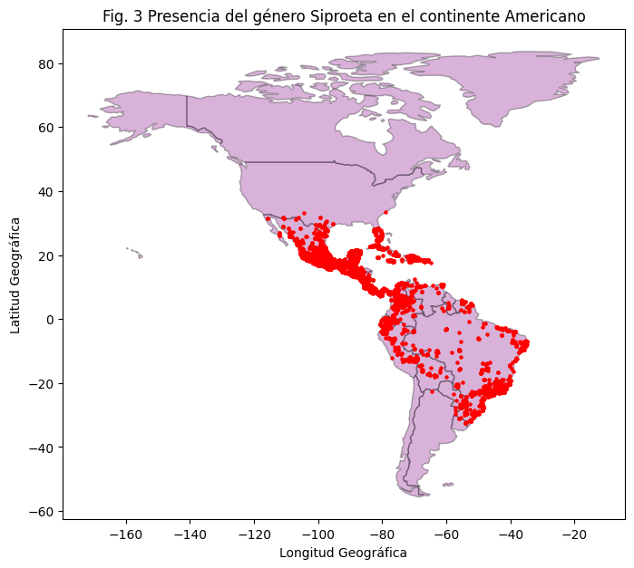

```python
fig, ax = plt.subplots(figsize=(8, 8))

# Capa de países de América
paises_america.plot(
    ax=ax,
    color="purple",
    alpha = 0.3,
    edgecolor="black"
)

# Registros de la Siproeta stelens y Siproeta stelenes biplagiata en el continente americano
malaquita_gdf.plot(
    ax=ax,
    marker="o",
    color="red",
    markersize=5
)
ax.set_title("Fig. 3 Presencia del género Siproeta en el continente Americano")
ax.set_xlabel("Longitud Geográfica")
ax.set_ylabel("Latitud Geográfica")
```

### **Se procedió a realizar la unión espacial de los archivos de los países de América y el conteo de observaciones de la especie *Siproeta stelenes* por país**

> Solo 26 países en el continente Americano presentan registros de la especie.

```python
paises_america.set_index('ADM0_ISO', inplace=True)
```

```python
paises_america
```

| ADM0_ISO | featurecla | scalerank | LABELRANK | SOVEREIGNT | SOV_A3 | ADM0_DIF | LEVEL | TYPE | TLC | ADMIN | ... | FCLASS_TR | FCLASS_ID | FCLASS_PL | FCLASS_GR | FCLASS_IT | FCLASS_NL | FCLASS_SE | FCLASS_BD | FCLASS_UA | geometry |
| --- | --- | --- | --- | --- | --- | --- | --- | --- | --- | --- | --- | --- | --- | --- | --- | --- | --- | --- | --- | --- | --- |
| CAN | Admin-0 country | 1 | 2 | Canada | CAN | 0 | 2 | Sovereign country | 1 | Canada | ... | None | None | None | None | None | None | None | None | None | MULTIPOLYGON (((-122.84 49, -122.97421 49.0025... |
| USA | Admin-0 country | 1 | 2 | United States of America | US1 | 1 | 2 | Country | 1 | United States of America | ... | None | None | None | None | None | None | None | None | None | MULTIPOLYGON (((-122.84 49, -120 49, -117.0312... |
| ARG | Admin-0 country | 1 | 2 | Argentina | ARG | 0 | 2 | Sovereign country | 1 | Argentina | ... | None | None | None | None | None | None | None | None | None | MULTIPOLYGON (((-68.63401 -52.63637, -68.25 -5... |
| CHL | Admin-0 country | 1 | 2 | Chile | CHL | 0 | 2 | Sovereign country | 1 | Chile | ... | None | None | None | None | None | None | None | None | None | MULTIPOLYGON (((-68.63401 -52.63637, -68.63335... |
| HTI | Admin-0 country | 1 | 5 | Haiti | HTI | 0 | 2 | Sovereign country | 1 | Haiti | ... | None | None | None | None | None | None | None | None | None | MULTIPOLYGON (((-71.71236 19.71446, -71.62487 ... |
| DOM | Admin-0 country | 1 | 5 | Dominican Republic | DOM | 0 | 2 | Sovereign country | 1 | Dominican Republic | ... | None | None | None | None | None | None | None | None | None | MULTIPOLYGON (((-71.7083 18.045, -71.68774 18.... |
| BHS | Admin-0 country | 1 | 4 | The Bahamas | BHS | 0 | 2 | Sovereign country | 1 | The Bahamas | ... | None | None | None | None | None | None | None | None | None | MULTIPOLYGON (((-78.98 26.79, -78.51 26.87, -7... |
| B12 | Admin-0 country | 1 | 5 | United Kingdom | GB1 | 1 | 2 | Disputed | 1 | Falkland Islands | ... | None | None | None | None | None | None | None | None | None | MULTIPOLYGON (((-61.2 -51.85, -60 -51.25, -59.... |
| GRL | Admin-0 country | 1 | 3 | Denmark | DN1 | 1 | 2 | Country | 1 | Greenland | ... | None | None | None | None | None | None | None | None | None | MULTIPOLYGON (((-46.76379 82.62796, -43.40644 ... |
| MEX | Admin-0 country | 1 | 2 | Mexico | MEX | 0 | 2 | Sovereign country | 1 | Mexico | ... | None | None | None | None | None | None | None | None | None | MULTIPOLYGON (((-117.12776 32.53534, -115.9913... |
| URY | Admin-0 country | 1 | 4 | Uruguay | URY | 0 | 2 | Sovereign country | 1 | Uruguay | ... | None | None | None | None | None | None | None | None | None | MULTIPOLYGON (((-57.62513 -30.21629, -56.97603... |
| BRA | Admin-0 country | 1 | 2 | Brazil | BRA | 0 | 2 | Sovereign country | 1 | Brazil | ... | None | None | None | None | None | None | None | None | None | MULTIPOLYGON (((-53.37366 -33.76838, -53.65054... |
| BOL | Admin-0 country | 1 | 3 | Bolivia | BOL | 0 | 2 | Sovereign country | 1 | Bolivia | ... | None | None | None | None | None | None | None | None | None | MULTIPOLYGON (((-69.52968 -10.95173, -68.78616... |
| PER | Admin-0 country | 1 | 2 | Peru | PER | 0 | 2 | Sovereign country | 1 | Peru | ... | None | None | None | None | None | None | None | None | None | MULTIPOLYGON (((-69.89364 -4.29819, -70.79477 ... |
| COL | Admin-0 country | 1 | 2 | Colombia | COL | 0 | 2 | Sovereign country | 1 | Colombia | ... | None | None | None | None | None | None | None | None | None | MULTIPOLYGON (((-66.87633 1.25336, -67.06505 1... |
| PAN | Admin-0 country | 1 | 4 | Panama | PAN | 0 | 2 | Sovereign country | 1 | Panama | ... | None | None | None | None | None | None | None | None | None | MULTIPOLYGON (((-77.35336 8.6705, -77.47472 8.... |
| CRI | Admin-0 country | 1 | 5 | Costa Rica | CRI | 0 | 2 | Sovereign country | 1 | Costa Rica | ... | None | None | None | None | None | None | None | None | None | MULTIPOLYGON (((-82.5462 9.56613, -82.93289 9.... |
| NIC | Admin-0 country | 1 | 5 | Nicaragua | NIC | 0 | 2 | Sovereign country | 1 | Nicaragua | ... | None | None | None | None | None | None | None | None | None | MULTIPOLYGON (((-83.65561 10.93876, -83.89505 ... |
| HND | Admin-0 country | 1 | 5 | Honduras | HND | 0 | 2 | Sovereign country | 1 | Honduras | ... | None | None | None | None | None | None | None | None | None | MULTIPOLYGON (((-83.14722 14.99583, -83.48999 ... |
| SLV | Admin-0 country | 1 | 6 | El Salvador | SLV | 0 | 2 | Sovereign country | 1 | El Salvador | ... | None | None | None | None | None | None | None | None | None | MULTIPOLYGON (((-89.35333 14.42413, -89.05851 ... |
| GTM | Admin-0 country | 1 | 3 | Guatemala | GTM | 0 | 2 | Sovereign country | 1 | Guatemala | ... | None | None | None | None | None | None | None | None | None | MULTIPOLYGON (((-92.22775 14.53883, -92.20323 ... |
| BLZ | Admin-0 country | 1 | 6 | Belize | BLZ | 0 | 2 | Sovereign country | 1 | Belize | ... | None | None | None | None | None | None | None | None | None | MULTIPOLYGON (((-89.14308 17.80832, -89.15091 ... |
| VEN | Admin-0 country | 1 | 3 | Venezuela | VEN | 0 | 2 | Sovereign country | 1 | Venezuela | ... | None | None | None | None | None | None | None | None | None | MULTIPOLYGON (((-60.73357 5.20028, -60.60118 4... |
| GUY | Admin-0 country | 1 | 4 | Guyana | GUY | 0 | 2 | Sovereign country | 1 | Guyana | ... | None | None | None | None | None | None | None | None | None | MULTIPOLYGON (((-56.53939 1.89952, -56.7827 1.... |
| SUR | Admin-0 country | 1 | 4 | Suriname | SUR | 0 | 2 | Sovereign country | 1 | Suriname | ... | None | None | None | None | None | None | None | None | None | MULTIPOLYGON (((-54.52475 2.31185, -55.09759 2... |
| ECU | Admin-0 country | 1 | 3 | Ecuador | ECU | 0 | 2 | Sovereign country | 1 | Ecuador | ... | None | None | None | None | None | None | None | None | None | MULTIPOLYGON (((-75.37322 -0.15203, -75.23372 ... |
| PRI | Admin-0 country | 1 | 5 | United States of America | US1 | 1 | 2 | Dependency | 1 | Puerto Rico | ... | None | None | None | None | None | None | None | None | None | MULTIPOLYGON (((-66.28243 18.51476, -65.7713 1... |
| JAM | Admin-0 country | 1 | 4 | Jamaica | JAM | 0 | 2 | Sovereign country | 1 | Jamaica | ... | None | None | None | None | None | None | None | None | None | MULTIPOLYGON (((-77.5696 18.49053, -76.89662 1... |
| CUB | Admin-0 country | 1 | 3 | Cuba | CU1 | 1 | 1 | Sovereignty | 1 | Cuba | ... | None | None | None | None | None | None | None | None | None | MULTIPOLYGON (((-82.26815 23.18861, -81.40446 ... |
| PRY | Admin-0 country | 1 | 4 | Paraguay | PRY | 0 | 2 | Sovereign country | 1 | Paraguay | ... | None | None | None | None | None | None | None | None | None | MULTIPOLYGON (((-58.16639 -20.1767, -57.87067 ... |
| TTO | Admin-0 country | 1 | 5 | Trinidad and Tobago | TTO | 0 | 2 | Sovereign country | 1 | Trinidad and Tobago | ... | None | None | None | None | None | None | None | None | None | MULTIPOLYGON (((-61.68 10.76, -61.105 10.89, -... |

31 rows × 168 columns

```python
malaquita_pais = malaquita_gdf.sjoin(
    paises_america,
    predicate='intersects'
)

malaquita_pais[['gbifID', 'species', 'ADM0_ISO', 'NAME', 'POP_EST']].head()
```

|  | gbifID | species | ADM0_ISO | NAME | POP_EST |
| --- | --- | --- | --- | --- | --- |
| 0 | 923915340 | Siproeta stelenes | MEX | Mexico | 127575529.0 |
| 1 | 911498184 | Siproeta stelenes | MEX | Mexico | 127575529.0 |
| 2 | 899978592 | Siproeta stelenes | MEX | Mexico | 127575529.0 |
| 3 | 899973827 | Siproeta stelenes | MEX | Mexico | 127575529.0 |
| 4 | 899959309 | Siproeta stelenes | MEX | Mexico | 127575529.0 |

```python
malaquita_conteo_pais = malaquita_pais.groupby("ADM0_ISO").gbifID.nunique()
malaquita_conteo_pais = malaquita_conteo_pais.reset_index()
malaquita_conteo_pais.set_index('ADM0_ISO', inplace=True)
malaquita_conteo_pais.rename(columns = {'gbifID': 'registros'}, inplace = True)
malaquita_conteo_pais.sort_values(by="registros", ascending=False)
malaquita_conteo_pais
```

| ADM0_ISO | registros |
| --- | --- |
| ARG | 203 |
| BLZ | 80 |
| BOL | 37 |
| BRA | 987 |
| COL | 591 |
| CRI | 1130 |
| CUB | 121 |
| DOM | 154 |
| ECU | 279 |
| GTM | 92 |
| GUY | 8 |
| HND | 225 |
| HTI | 5 |
| JAM | 50 |
| MEX | 9480 |
| NIC | 198 |
| PAN | 448 |
| PER | 189 |
| PRI | 182 |
| PRY | 22 |
| SLV | 88 |
| SUR | 39 |
| TTO | 52 |
| URY | 9 |
| USA | 525 |
| VEN | 36 |

```python
#len(malaquita_conteo_pais)
```

### **Se realizo la unión (no espacial) del mapa de area geográfica de América con los resultados del conteo de la especie por país, generando el gráfico de mapa con coropletas.**

> Alaska es un estado perteneciente a los [USA](https://es.wikipedia.org/wiki/Estados_Unidos), no existen registros de la especie *Siproeta stelenes* en Alaska.  
> En los países sin registros (NAN) se cambiaron a valor numérico de 0.0

```python
malaquita_riqueza_gdf = paises_america.join(malaquita_conteo_pais)
```

```python
malaquita_riqueza_gdf.head()
```

| ADM0_ISO | featurecla | scalerank | LABELRANK | SOVEREIGNT | SOV_A3 | ADM0_DIF | LEVEL | TYPE | TLC | ADMIN | ... | FCLASS_ID | FCLASS_PL | FCLASS_GR | FCLASS_IT | FCLASS_NL | FCLASS_SE | FCLASS_BD | FCLASS_UA | geometry | registros |
| --- | --- | --- | --- | --- | --- | --- | --- | --- | --- | --- | --- | --- | --- | --- | --- | --- | --- | --- | --- | --- | --- |
| CAN | Admin-0 country | 1 | 2 | Canada | CAN | 0 | 2 | Sovereign country | 1 | Canada | ... | None | None | None | None | None | None | None | None | MULTIPOLYGON (((-122.84 49, -122.97421 49.0025... | NaN |
| USA | Admin-0 country | 1 | 2 | United States of America | US1 | 1 | 2 | Country | 1 | United States of America | ... | None | None | None | None | None | None | None | None | MULTIPOLYGON (((-122.84 49, -120 49, -117.0312... | 525.0 |
| ARG | Admin-0 country | 1 | 2 | Argentina | ARG | 0 | 2 | Sovereign country | 1 | Argentina | ... | None | None | None | None | None | None | None | None | MULTIPOLYGON (((-68.63401 -52.63637, -68.25 -5... | 203.0 |
| CHL | Admin-0 country | 1 | 2 | Chile | CHL | 0 | 2 | Sovereign country | 1 | Chile | ... | None | None | None | None | None | None | None | None | MULTIPOLYGON (((-68.63401 -52.63637, -68.63335... | NaN |
| HTI | Admin-0 country | 1 | 5 | Haiti | HTI | 0 | 2 | Sovereign country | 1 | Haiti | ... | None | None | None | None | None | None | None | None | MULTIPOLYGON (((-71.71236 19.71446, -71.62487 ... | 5.0 |

5 rows × 169 columns

```python
malaquita_riqueza_gdf["registros"].fillna(value = 0.0, inplace = True)
```

```python
malaquita_riqueza_gdf.head()
```

| ADM0_ISO | featurecla | scalerank | LABELRANK | SOVEREIGNT | SOV_A3 | ADM0_DIF | LEVEL | TYPE | TLC | ADMIN | ... | FCLASS_ID | FCLASS_PL | FCLASS_GR | FCLASS_IT | FCLASS_NL | FCLASS_SE | FCLASS_BD | FCLASS_UA | geometry | registros |
| --- | --- | --- | --- | --- | --- | --- | --- | --- | --- | --- | --- | --- | --- | --- | --- | --- | --- | --- | --- | --- | --- |
| CAN | Admin-0 country | 1 | 2 | Canada | CAN | 0 | 2 | Sovereign country | 1 | Canada | ... | None | None | None | None | None | None | None | None | MULTIPOLYGON (((-122.84 49, -122.97421 49.0025... | 0.0 |
| USA | Admin-0 country | 1 | 2 | United States of America | US1 | 1 | 2 | Country | 1 | United States of America | ... | None | None | None | None | None | None | None | None | MULTIPOLYGON (((-122.84 49, -120 49, -117.0312... | 525.0 |
| ARG | Admin-0 country | 1 | 2 | Argentina | ARG | 0 | 2 | Sovereign country | 1 | Argentina | ... | None | None | None | None | None | None | None | None | MULTIPOLYGON (((-68.63401 -52.63637, -68.25 -5... | 203.0 |
| CHL | Admin-0 country | 1 | 2 | Chile | CHL | 0 | 2 | Sovereign country | 1 | Chile | ... | None | None | None | None | None | None | None | None | MULTIPOLYGON (((-68.63401 -52.63637, -68.63335... | 0.0 |
| HTI | Admin-0 country | 1 | 5 | Haiti | HTI | 0 | 2 | Sovereign country | 1 | Haiti | ... | None | None | None | None | None | None | None | None | MULTIPOLYGON (((-71.71236 19.71446, -71.62487 ... | 5.0 |

5 rows × 169 columns

### **Se genera un gráfico de coropletas que muestre la riqueza de la especie *Siproeta* en cada país del continente Americano.**

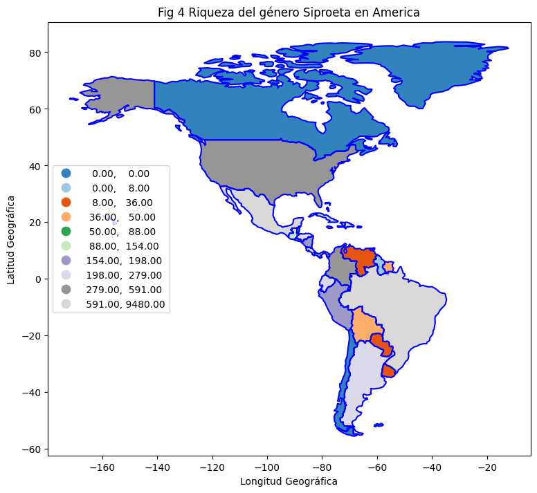

```python
fig, ax = plt.subplots(figsize=(9, 9))
malaquita_riqueza_gdf.plot(
    ax = ax,
    column="registros",
    legend=True,
    cmap='tab20c',
    scheme='quantiles',
    k = 10,
    legend_kwds={"loc": "center left"}
)
paises_america.boundary.plot(ax = ax, color = "blue")
ax.set_title("Fig 4 Riqueza del género Siproeta en America")
ax.set_xlabel("Longitud Geográfica")
ax.set_ylabel("Latitud Geográfica")
```

### **Se genera un achivo [*ESRI shapefile*](https://www.esri.com/content/dam/esrisites/sitecore-archive/Files/Pdfs/library/whitepapers/pdfs/shapefile.pdf) con la información de la riqueza de la especie "*Siproeta*".**

```python
malaquita_riqueza_gdf.to_file("malaquita_riqueza.shp")
```

```python
#display(malaquita_riqueza_gdf)
```

[output not shown]

```python
# Biblioteca requerida para mapas interactivos
!pip install mapclassify --quiet

import mapclassify
```

### **Uso de capas raster**

> BIO1 = Annual Mean Temperature (Temperatura Promedio Anual)  
> BIO7 = Temperature Annual Range (BIO5-BIO6) (Rango Anual de Temperatura)  
> BIO12 = Annual Precipitation (Precipitación Anual)  
> Elev = Elevaciones snmm

Son factores que influyen / determinan la ecología, el hábitat, la biodiversidad, la distribución geográfica y los nichos ecológicos de las diversidades de especies existentes.

### **Se importa e instala la libería [*rasterio*](https://rasterio.readthedocs.io/en/stable/) para manejo de archivos [*raster*](https://www.britannica.com/technology/raster-graphics)**

```python
# Instalación de rasterio
!pip install rasterio --quiet

# Carga de rasterio
import rasterio

# Carga de rasterio.plot (para graficar datos raster)
import rasterio.plot
```

```
   ━━━━━━━━━━━━━━━━━━━━━━━━━━━━━━━━━━━━━━━━ 22.2/22.2 MB 50.7 MB/s eta 0:00:00
```

```python
# Carga de rasterio
import rasterio

# Carga de rasterio.plot (para graficar datos raster)
import rasterio.plot
```

### **Se cargan las capas raster seleccionadas:**

> annual mean temperature  
> annual precipitation  
> temperature annual range  
> elevations

Se procede a generar los gráficos de cada una de las capas raster importadas.

```python
annual_mean_temperature = rasterio.open("wc2.1_2.5m_bio_1.tif")
temperature_annual_range = rasterio.open("wc2.1_2.5m_bio_7.tif")
annual_precipitation = rasterio.open("wc2.1_2.5m_bio_12.tif")
elevaciones = rasterio.open("wc2.1_2.5m_elev.tif")
```

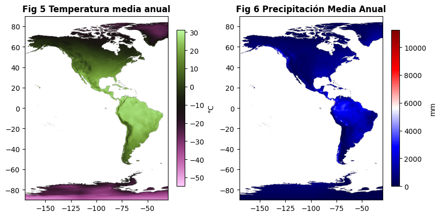

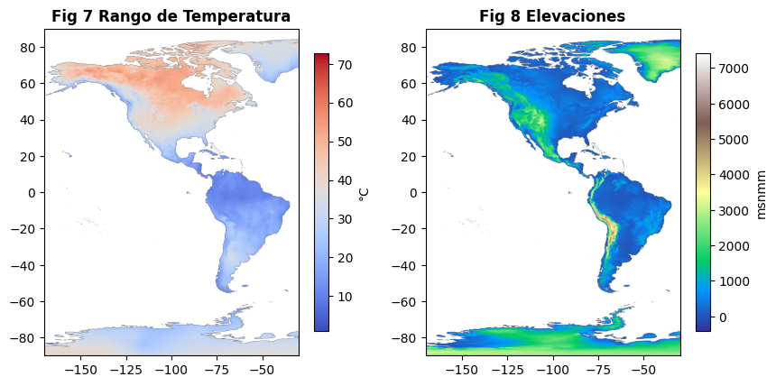

```python
fig, (ax1, ax2) = plt.subplots(nrows = 1, ncols = 2,
                               figsize=(10, 8),
                               sharex = False, sharey = False)
ax1 = rasterio.plot.show(annual_mean_temperature,
    cmap="vanimo", # colores
    ax=ax1,
    title="Fig 5 Temperatura media anual")
# Agregar una leyenda
cbar = fig.colorbar(ax1.images[0], ax=ax1, shrink=0.5)
cbar.set_label('°C')

# Limitar el rango de los ejes
ax1.set_xlim(-170.0, -30.0)
ax1.set_ylim(-90.0, 90.0)

ax2 = rasterio.plot.show(annual_precipitation,
                       cmap="seismic",
                       ax = ax2,
                       title= "Fig 6 Precipitación Media Anual")
cbar = fig.colorbar(ax2.images[0], ax=ax2, shrink=0.5)
cbar.set_label('mm')
ax2.set_xlim(-170.0, -30.0)
ax2.set_ylim(-90.0, 90.0)
plt.savefig("Rasters1.png")

fig, (ax3, ax4) = plt.subplots(nrows = 1, ncols = 2,
                               figsize=(10, 8),
                               sharex = False, sharey = False)
ax3 = rasterio.plot.show(temperature_annual_range,
                         cmap = "coolwarm",
                         ax = ax3,
                         title = "Fig 7 Rango de Temperatura")
cbar = fig.colorbar(ax3.images[0], ax=ax3, shrink=0.5)
cbar.set_label('°C')
ax3.set_xlim(-170.0, -30.0)
ax3.set_ylim(-90.0, 90.0)

ax4 = rasterio.plot.show(elevaciones,
                         cmap = "terrain",
                         ax = ax4,
                         title = "Fig 8 Elevaciones")
cbar = fig.colorbar(ax4.images[0], ax=ax4, shrink=0.5)
cbar.set_label('msnmm')
ax4.set_xlim(-170.0, -30.0)
ax4.set_ylim(-90.0, 90.0)

plt.savefig("Rasters2.png")
plt.show()
```

### **Se genera un mapa interactivo con los datos obtenidos de la especie y las capas raster**

Se instala la librería [*leafmap*](https://leafmap.org/)

```python
!pip install leafmap --quiet
!pip install localtileserver --quiet

import leafmap
import leafmap.colormaps as cm
from matplotlib.colors import LinearSegmentedColormap #Rampas de Colores
from google.colab import output
output.enable_custom_widget_manager() #Widget de Java Script
```

[output not shown]

```python
malaquita_riqueza_shp = gpd.read_file(f"malaquita_riqueza.shp")
malaquita_riqueza_shp["area"] = malaquita_riqueza_shp.area
malaquita_riqueza_shp["boundary"] = malaquita_riqueza_shp.boundary
malaquita_riqueza_shp["centroid"] = malaquita_riqueza_shp.centroid
malaquita_riqueza_shp
```

|  | ADM0_ISO | featurecla | scalerank | LABELRANK | SOVEREIGNT | SOV_A3 | ADM0_DIF | LEVEL | TYPE | TLC | ... | FCLASS_IT | FCLASS_NL | FCLASS_SE | FCLASS_BD | FCLASS_UA | registros | geometry | area | boundary | centroid |
| --- | --- | --- | --- | --- | --- | --- | --- | --- | --- | --- | --- | --- | --- | --- | --- | --- | --- | --- | --- | --- | --- |
| 0 | CAN | Admin-0 country | 1 | 2 | Canada | CAN | 0 | 2 | Sovereign country | 1 | ... | None | None | None | None | None | NaN | MULTIPOLYGON (((-122.84 49, -122.97421 49.0025... | 1712.995228 | MULTILINESTRING ((-122.84 49, -122.97421 49.00... | POINT (-98.14238 61.46908) |
| 1 | USA | Admin-0 country | 1 | 2 | United States of America | US1 | 1 | 2 | Country | 1 | ... | None | None | None | None | None | 525.0 | MULTIPOLYGON (((-122.84 49, -120 49, -117.0312... | 1122.281921 | MULTILINESTRING ((-122.84 49, -120 49, -117.03... | POINT (-112.59944 45.70563) |
| 2 | ARG | Admin-0 country | 1 | 2 | Argentina | ARG | 0 | 2 | Sovereign country | 1 | ... | None | None | None | None | None | 203.0 | MULTIPOLYGON (((-68.63401 -52.63637, -68.25 -5... | 278.923392 | MULTILINESTRING ((-68.63401 -52.63637, -68.25 ... | POINT (-65.17536 -35.44682) |
| 3 | CHL | Admin-0 country | 1 | 2 | Chile | CHL | 0 | 2 | Sovereign country | 1 | ... | None | None | None | None | None | NaN | MULTIPOLYGON (((-68.63401 -52.63637, -68.63335... | 86.508469 | MULTILINESTRING ((-68.63401 -52.63637, -68.633... | POINT (-71.52064 -39.04701) |
| 4 | HTI | Admin-0 country | 1 | 5 | Haiti | HTI | 0 | 2 | Sovereign country | 1 | ... | None | None | None | None | None | 5.0 | POLYGON ((-71.71236 19.71446, -71.62487 19.169... | 2.447114 | LINESTRING (-71.71236 19.71446, -71.62487 19.1... | POINT (-72.65801 18.9007) |
| 5 | DOM | Admin-0 country | 1 | 5 | Dominican Republic | DOM | 0 | 2 | Sovereign country | 1 | ... | None | None | None | None | None | 154.0 | POLYGON ((-71.7083 18.045, -71.68774 18.31666,... | 4.129206 | LINESTRING (-71.7083 18.045, -71.68774 18.3166... | POINT (-70.46236 18.88449) |
| 6 | BHS | Admin-0 country | 1 | 4 | The Bahamas | BHS | 0 | 2 | Sovereign country | 1 | ... | None | None | None | None | None | NaN | MULTIPOLYGON (((-78.98 26.79, -78.51 26.87, -7... | 1.399757 | MULTILINESTRING ((-78.98 26.79, -78.51 26.87, ... | POINT (-77.92997 25.51549) |
| 7 | B12 | Admin-0 country | 1 | 5 | United Kingdom | GB1 | 1 | 2 | Disputed | 1 | ... | None | None | None | None | None | NaN | POLYGON ((-61.2 -51.85, -60 -51.25, -59.15 -51... | 2.128750 | LINESTRING (-61.2 -51.85, -60 -51.25, -59.15 -... | POINT (-59.42097 -51.71322) |
| 8 | GRL | Admin-0 country | 1 | 3 | Denmark | DN1 | 1 | 2 | Country | 1 | ... | None | None | None | None | None | NaN | POLYGON ((-46.76379 82.62796, -43.40644 83.225... | 677.509565 | LINESTRING (-46.76379 82.62796, -43.40644 83.2... | POINT (-41.50018 74.77049) |
| 9 | MEX | Admin-0 country | 1 | 2 | Mexico | MEX | 0 | 2 | Sovereign country | 1 | ... | None | None | None | None | None | 9480.0 | POLYGON ((-117.12776 32.53534, -115.99135 32.6... | 175.207341 | LINESTRING (-117.12776 32.53534, -115.99135 32... | POINT (-102.57635 23.93537) |
| 10 | URY | Admin-0 country | 1 | 4 | Uruguay | URY | 0 | 2 | Sovereign country | 1 | ... | None | None | None | None | None | 9.0 | POLYGON ((-57.62513 -30.21629, -56.97603 -30.1... | 17.027171 | LINESTRING (-57.62513 -30.21629, -56.97603 -30... | POINT (-56.00328 -32.7809) |
| 11 | BRA | Admin-0 country | 1 | 2 | Brazil | BRA | 0 | 2 | Sovereign country | 1 | ... | None | None | None | None | None | 987.0 | POLYGON ((-53.37366 -33.76838, -53.65054 -33.2... | 710.185243 | LINESTRING (-53.37366 -33.76838, -53.65054 -33... | POINT (-53.05434 -10.80677) |
| 12 | BOL | Admin-0 country | 1 | 3 | Bolivia | BOL | 0 | 2 | Sovereign country | 1 | ... | None | None | None | None | None | 37.0 | POLYGON ((-69.52968 -10.95173, -68.78616 -11.0... | 92.077173 | LINESTRING (-69.52968 -10.95173, -68.78616 -11... | POINT (-64.64141 -16.72899) |
| 13 | PER | Admin-0 country | 1 | 2 | Peru | PER | 0 | 2 | Sovereign country | 1 | ... | None | None | None | None | None | 189.0 | POLYGON ((-69.89364 -4.29819, -70.79477 -4.251... | 108.049821 | LINESTRING (-69.89364 -4.29819, -70.79477 -4.2... | POINT (-74.39181 -9.19156) |
| 14 | COL | Admin-0 country | 1 | 2 | Colombia | COL | 0 | 2 | Sovereign country | 1 | ... | None | None | None | None | None | 591.0 | POLYGON ((-66.87633 1.25336, -67.06505 1.13011... | 93.945155 | LINESTRING (-66.87633 1.25336, -67.06505 1.130... | POINT (-73.07773 3.92721) |
| 15 | PAN | Admin-0 country | 1 | 4 | Panama | PAN | 0 | 2 | Sovereign country | 1 | ... | None | None | None | None | None | 448.0 | POLYGON ((-77.35336 8.6705, -77.47472 8.52429,... | 6.181283 | LINESTRING (-77.35336 8.6705, -77.47472 8.5242... | POINT (-80.10916 8.53002) |
| 16 | CRI | Admin-0 country | 1 | 5 | Costa Rica | CRI | 0 | 2 | Sovereign country | 1 | ... | None | None | None | None | None | 1130.0 | POLYGON ((-82.5462 9.56613, -82.93289 9.47681,... | 4.438723 | LINESTRING (-82.5462 9.56613, -82.93289 9.4768... | POINT (-84.17542 9.96567) |
| 17 | NIC | Admin-0 country | 1 | 5 | Nicaragua | NIC | 0 | 2 | Sovereign country | 1 | ... | None | None | None | None | None | 198.0 | POLYGON ((-83.65561 10.93876, -83.89505 10.726... | 10.788943 | LINESTRING (-83.65561 10.93876, -83.89505 10.7... | POINT (-85.02032 12.84819) |
| 18 | HND | Admin-0 country | 1 | 5 | Honduras | HND | 0 | 2 | Sovereign country | 1 | ... | None | None | None | None | None | 225.0 | POLYGON ((-83.14722 14.99583, -83.48999 15.016... | 9.554616 | LINESTRING (-83.14722 14.99583, -83.48999 15.0... | POINT (-86.58996 14.82295) |
| 19 | SLV | Admin-0 country | 1 | 6 | El Salvador | SLV | 0 | 2 | Sovereign country | 1 | ... | None | None | None | None | None | 88.0 | POLYGON ((-89.35333 14.42413, -89.05851 14.340... | 1.746088 | LINESTRING (-89.35333 14.42413, -89.05851 14.3... | POINT (-88.8729 13.72609) |
| 20 | GTM | Admin-0 country | 1 | 3 | Guatemala | GTM | 0 | 2 | Sovereign country | 1 | ... | None | None | None | None | None | 92.0 | POLYGON ((-92.22775 14.53883, -92.20323 14.830... | 9.228473 | LINESTRING (-92.22775 14.53883, -92.20323 14.8... | POINT (-90.36946 15.69936) |
| 21 | BLZ | Admin-0 country | 1 | 6 | Belize | BLZ | 0 | 2 | Sovereign country | 1 | ... | None | None | None | None | None | 80.0 | POLYGON ((-89.14308 17.80832, -89.15091 17.955... | 1.872603 | LINESTRING (-89.14308 17.80832, -89.15091 17.9... | POINT (-88.70342 17.19709) |
| 22 | VEN | Admin-0 country | 1 | 3 | Venezuela | VEN | 0 | 2 | Sovereign country | 1 | ... | None | None | None | None | None | 36.0 | POLYGON ((-60.73357 5.20028, -60.60118 4.9181,... | 74.438502 | LINESTRING (-60.73357 5.20028, -60.60118 4.918... | POINT (-66.16383 7.16213) |
| 23 | GUY | Admin-0 country | 1 | 4 | Guyana | GUY | 0 | 2 | Sovereign country | 1 | ... | None | None | None | None | None | 8.0 | POLYGON ((-56.53939 1.89952, -56.7827 1.86371,... | 17.110779 | LINESTRING (-56.53939 1.89952, -56.7827 1.8637... | POINT (-58.9712 4.79023) |
| 24 | SUR | Admin-0 country | 1 | 4 | Suriname | SUR | 0 | 2 | Sovereign country | 1 | ... | None | None | None | None | None | 39.0 | POLYGON ((-54.52475 2.31185, -55.09759 2.52375... | 11.751504 | LINESTRING (-54.52475 2.31185, -55.09759 2.523... | POINT (-55.91146 4.12001) |
| 25 | ECU | Admin-0 country | 1 | 3 | Ecuador | ECU | 0 | 2 | Sovereign country | 1 | ... | None | None | None | None | None | 279.0 | POLYGON ((-75.37322 -0.15203, -75.23372 -0.911... | 20.382425 | LINESTRING (-75.37322 -0.15203, -75.23372 -0.9... | POINT (-78.38417 -1.45477) |
| 26 | PRI | Admin-0 country | 1 | 5 | United States of America | US1 | 1 | 2 | Dependency | 1 | ... | None | None | None | None | None | 182.0 | POLYGON ((-66.28243 18.51476, -65.7713 18.4266... | 0.788009 | LINESTRING (-66.28243 18.51476, -65.7713 18.42... | POINT (-66.47922 18.23722) |
| 27 | JAM | Admin-0 country | 1 | 4 | Jamaica | JAM | 0 | 2 | Sovereign country | 1 | ... | None | None | None | None | None | 50.0 | POLYGON ((-77.5696 18.49053, -76.89662 18.4008... | 1.063979 | LINESTRING (-77.5696 18.49053, -76.89662 18.40... | POINT (-77.32425 18.13764) |
| 28 | CUB | Admin-0 country | 1 | 3 | Cuba | CU1 | 1 | 1 | Sovereignty | 1 | ... | None | None | None | None | None | 121.0 | POLYGON ((-82.26815 23.18861, -81.40446 23.117... | 10.022627 | LINESTRING (-82.26815 23.18861, -81.40446 23.1... | POINT (-78.96068 21.63175) |
| 29 | PRY | Admin-0 country | 1 | 4 | Paraguay | PRY | 0 | 2 | Sovereign country | 1 | ... | None | None | None | None | None | 22.0 | POLYGON ((-58.16639 -20.1767, -57.87067 -20.73... | 35.429306 | LINESTRING (-58.16639 -20.1767, -57.87067 -20.... | POINT (-58.38739 -23.24804) |
| 30 | TTO | Admin-0 country | 1 | 5 | Trinidad and Tobago | TTO | 0 | 2 | Sovereign country | 1 | ... | None | None | None | None | None | 52.0 | POLYGON ((-61.68 10.76, -61.105 10.89, -60.895... | 0.639000 | LINESTRING (-61.68 10.76, -61.105 10.89, -60.8... | POINT (-61.33037 10.42824) |

31 rows × 173 columns

```python
m = leafmap.Map(
    center=(0.0, -80.0),
    zoom=2, # Rango 1 - 20
    width="800px",
    height="800px",
    #zoom_control=True,
    #draw_control=False,
    #scale_control=True,
    fullscreen_control=False,
    attribution_control=False,
    toolbar_control=True
)

m.add_raster(
    elevaciones,
    colormap='coolwarm',
    layer_name='Elevación snmm'
)

m.add_data(malaquita_riqueza_gdf,
           column = "registros",
           scheme='quantiles',
           cmap='viridis',
           layer_name= "Riqueza Siproeta",
           legend_title= "Riqueza Siproeta"
           #tooltip=['ADMIN', 'registros']
           )

m
```

[output not shown]

## **Referencias:**

> [Britannica](https://www.britannica.com/technology/raster-graphics)  
> [CEUPE](https://www.ceupe.com/)  
> [Diccionario de la lengua española](https://dle.rae.es)  
> [EPSG](https://epsg.org/home.html)  
> [ESRI Shapefile](https://www.esri.com/content/dam/esrisites/sitecore-archive/Files/Pdfs/library/whitepapers/pdfs/shapefile.pdf)  
> [GBIF](https://www.gbif.org/)  
> [GEOPACKAGE](https://www.geopackage.org/guidance/getting-started.html)  
> [GeoPandas](https://geopandas.org/en/stable/)  
> [INaturalistMX](https://mexico.inaturalist.org/taxa/50336-Siproeta-stelenes)  
> [LeafMap](https://leafmap.org/)  
> [Pandas](https://pandas.pydata.org/docs/index.html)  
> [Phyton](https://www.python.org/)  
> [Rasterio](https://rasterio.readthedocs.io/en/stable/#)  
> [Scielo Mexico](https://www.scielo.org.mx/scielo.php?lng=es)  
> [Wikipedia](https://es.wikipedia.org/wiki/Wikipedia:Portada)  
> [Wiley online library](https://onlinelibrary.wiley.com/doi/full/10.1002/ece3.10553)  
> [WorldClim](https://www.worldclim.org/data/index.html)